# Problem Set 3 Empirical Methods

Patrick Glettig (13-252-143), Carmine Ragone (14-995-021)

19.11.2018

# Paper and Pencil Questions

## 1 Coefficient Interpretation

### a)

$$consumption_i = \beta_1 + \beta_2income_i + \delta_i$$
$$consumption_i = 5800.441 + 0.267income_i + \delta_i$$

A 1-unit increase in income (1 USD) would effect in an increased consumption of 0.267 USD.

### b)

$$consumption_i = \beta_1 + \beta_2income_i + \beta_3famsize + \upsilon_i$$
$$consumption_i = 4429.22 + 0.254income_i + 625.431famsize + \upsilon_i$$
A 1-unit increase in income (1 USD) would effect in an increased consumption of 0.254 USD, holding family size constant. Every additional family member increases consumption by 625 USD.

### c)

The coefficient on income is still 0.254, so the effect size did not change from the model in b). But we can now interpret it as: a 1-unit increase in income (1 USD) would effect in an increased consumption of 0.254 USD, controlling for family size and house owners.

### d)

The coefficients change from model (1) to model (2) as part of the coefficient in $income$ also reflected in $famsize$, a intuitive explanation would be that people with larger families have to work (& hence earn) more to feed the family which biases the effect of income. The coefficients $\beta_2$ and $\beta_3$ barely change from model (2) to model (3), so the fact that someone is owning a house did not explain any part of the coefficients on $income$ and $famsize$. As this makes model (3) inefficent, model (2) is the right one since it allows causal statements on the effect of income and family size on consumption. Furthermore, the standard error in house is almost as large as the coefficient itself, which hints to a bias or noise in the model.

## Omitted Variable Bias

### a)

$\hat{\alpha}_1$ is defined as:

$$\hat{\alpha}_1=\frac{cov(X_{1i},Y_i)}{var(X_{1i})}$$
Plug in $Y_i$ of the true model to find the conditional expectation:

$$\begin{align*}
E(\hat{\alpha}_1|X) &= \frac{\overbrace{cov(X_{1i},\beta_0)}^{=0}+\overbrace{cov(X_{1i},\beta_1X_{1i})}^{=\beta_1\space var(X_{1i})}+\overbrace{cov(X_{1i},\beta_2X_{2i})}^{=\beta_2\space cov(X_{1i},x_{2i})}+\overbrace{cov(X_{2i},\epsilon_i)}^{=0 \textrm{, under A2}}}{var(X_{1i})} \\
&= \beta_1 + \beta_2 \frac{cov(X_{1i},X_{2i})}{var(X_{1i})}=\beta_1 + \beta_2\hat{\beta}_{X_{2i}\space on \space X_{1i}} \tag{a}
\end{align*}$$

Where $\hat{\beta}_{X_{2i}\space on \space X_{1i}}$ is the OLS coefficient from the regression of $X_{2i}$ on $X_{1i}$.

### b)

From slide 30 in slidedeck 2a we can find two conditions for no omitted variable bias:

1. The variable omitted, $\beta_2=0$ or
2. $X_{1i}$ is uncorrelated with $X_{2i}$

For 1): the true data generation process includes $\beta_2$, so by definition it is not equal to zero (otherwise it would not be part of the true data generating process.)

For 2): field of study is likely to be correlated with the GPA, in other words $X_{1i}$ will most likely correlate with $X_{2i}$. From a statistical point of view, the probability that any two covariates are orthogonal is zero. We would assume that studying econ or finance is much harder because you have to take empirical methods so you will have a lower GPA.

By using $Y_i=\alpha_0+\alpha_1X_{1i}+\epsilon_i$, with $field of study$ a relevant variable is omitted, therefore $\hat\alpha_1$ is likely to be biased.

### c)

$$\hat\alpha_1=\beta_1 + \underbrace{\beta_2}_{\textrm{impact of} \space \beta_2 \space \textrm{on} \space Y} \underbrace{\frac{cov(X_{1i},X_{2i})}{var(X_{1i})}}_{Cor(GPA,EcoFin)}$$
$$\begin{align*}
E(\hat{\alpha}_1|X) &= \beta_1 + \beta_2\hat{\beta}_{X_{2i}\space on \space X_{1i}}
&= \beta_1 + \overbrace{\beta_2}^{\textrm{impact of} \space \beta_2 \space \textrm{on} \space Y}\overbrace{(X'_1 M_{-1}X_1)^-1X'_1M_{-1}X_{2}}^{Cor(GPA,EcoFin)}
\end{align*}$$

To identify the sign of the bias, we need to make assumptions on the two parts influencing the bias. *Impact of* $\beta_2$ *on Y* is assumed to be positive as the valuable skills you learned in Empirical Methods (which you had to take as part of *EcoFin*) pay off in the job market. *Correlation between GPA and EcoFin* is assumed to be negative because of the reasons we stated in b). As we multiply a positive number with a negative, the bias will be negative.

### d)

With $\beta_3$, the OVS bias changes to:

$$E(\hat\alpha_1|X)=\beta_1+\beta_2(X'_1 M_{-1}X_1)^{-1}X'_1M_{-1}X_{2}$$
where $(X'_1 M_{-1}X_1)^{-1}X'_1M_{-1}X_{2}$ would be the coefficient of an OLS regression of $\epsilon_{x_2}$ on $\epsilon_{x_1}$ after controlling for $x_3$.

Therefore, as opposed to questions 2c and 2d, there is now a conditional correlation between $x_1$ and $x_2$ as $x_1$ is controlled for $x_3$. The interpretation of the unconditional correlation in 1c would still hold, however we cannot be sure if the conditional correlation can be interpreted as the uncoditional one. Therefore the sign of the bias cannot be confidently be identified because there is less intuition for conditional correlation.

If we had to sign the conditional correlation, we would assume that the interpretation of the conditional correlation is similar to the one from the unconditional one. Under this assumption, we would conclude that the conditional covariance is negative and therefore, the addition of $x_3$ would not change our answer (i.e. the bias is still negative).

The bias will be less than before as with the addition of $x_3$, fewer variance in $Y$ is left for $x_1$.

## 3. Measurement Error in y

### a)

First of all, we derive the relationship between $\epsilon_i,\epsilon_i^*$ and $\eta_i$. Thus, we have:
$$\epsilon_i = y_i - \alpha_i -\beta x_i'$$
Plugging in the value of $y_i$ in the equation above we have:
$$\begin{align*}
\epsilon_i &= y_i^* + \eta_i - \alpha_i - \beta x_i' \\
&= \underbrace{y_i^* - \alpha_i -\beta x_i'}_{\epsilon_i^*} + \eta_i = \epsilon_i^* + \eta_i
\end{align*}$$

So it is possible to calculate the mean and the variance of $\epsilon_i$

Mean:

$$E[\epsilon_i ] = E[\epsilon_i^* + \eta_i ] = E[\epsilon_i^*] + E[\eta_i ] = 0 + 0 = 0$$
Variance:
$$Var[\epsilon_i ] = Var[\epsilon_i^* + \eta_i ] = Var[\epsilon_i^*] + Var[\eta_i ] + 2 Cov(\epsilon_i^*,\eta_i) = \sigma^2_* + \sigma^2_\eta$$
Note that the $Cov(\epsilon_i^*,\eta_i)$ is 0 because of the conditional expectaion of $\epsilon_i^*$ and $\eta_i$ is also 0.

### b)

We know that an estimator is unbiased only if the expected value of $\hat{\beta}$ is $\beta$ itself. So, we calculate $E[\hat{\beta}]$:

$$\begin{align*}
E[\widehat{\beta}] &= E[\beta + (X'X)^{-1}X'\epsilon_i] \\
&= \beta + (X'X)^{-1}X'E[\epsilon_i] \\
&= \beta + (X'X)^{-1}X'E[\epsilon_i^* + \eta_i] \\
&= \beta + (X'X)^{-1}X'\underbrace{E[\epsilon_i]}_{\text{=0, under A2}} + (X'X)^{-1}X'\underbrace{E[\eta_i]}_{\text{=0, given}} = \beta \\
\end{align*}$$

Therefore, we can conclude that the estimator is not biased.

# Empirical Part

Read data for empirical part:

```r
indicators <- fread("indicators.csv")
head(indicators)  # Check the format
dim(indicators)  #Check length
summary(indicators)  #Explore the data
```

[output not shown]

```r
Model1 = mortalityun ~ corruptionun
Model2 = hospital_deaths ~ corruptionun
Model3 = mortalityun ~ ruleoflaw
Model4 = govmort ~ corruptionun

lm1 <- lm(Model1, data = indicators, x = TRUE)
lm2 <- lm(Model2, data = indicators, x = TRUE)
lm3 <- lm(Model3, data = indicators, x = TRUE)
lm4 <- lm(Model4, data = indicators, x = TRUE)
```

## a)

**Child Mortality**: Every country might have a different definition of child mortality, e.g. until which age is a human defined as a child. Therefore, the UN reported measure might suffer from less bias since it proposes a unified measurement. If child mortality is self-reported, countries might have a need to present them better as they actually are, so there might be a downwards bias. Even the UN index cannot be guaranteed to be measured exactly the same way in each country, so it is likely that *child mortality* includes some measurement error.

**Corruption**: the variable for corruption, *corruptionun* is a measured by the UN and therefore uses a standardized framework. However, corruption might appear in different forms and depending on the type of measurement countries may have different scores although the effective corruption is the same. Also, even with the assumption that corruption appears in the same way in every country (and can thus be measured with a standardized index), the measurement must also be enforced the same way in every country, assuming we had neutral observators in every country. A standardized index by the UN is probably the best way to measure corruption, nevertheless it is not free from a possible measurement error.

## b)

### i)?

```r
lm1$coefficients
```

```
##  (Intercept) corruptionun
## 8.073839e-08 6.259262e-01
```

The p-value for a one-sided test where $\hat\beta>0$ is simply half of the p-value reported from the two-sided test $\hat\beta=0$ which is reported by R:

```r
anova(lm1)
```

|  | Df | Sum Sq | Mean Sq | F value | Pr(>F) |
| --- | --- | --- | --- | --- | --- |
| corruptionun | 1 | 34.86874 | 34.8687413 | 56.68535 | 4.200486e-11 |
| Residuals | 88 | 54.13126 | 0.6151279 | NA | NA |

```r
anova(lm1)[1, 5]/2
```

```
## [1] 2.100243e-11
```

### ii)

A one-unit increase in *corruptionun* increases *mortalityun* by $\sim0.63$. Given that both variables are standardized with mean zero and standard deviation one, this also equals an elasticity of 63%, a large effect.

### iii)

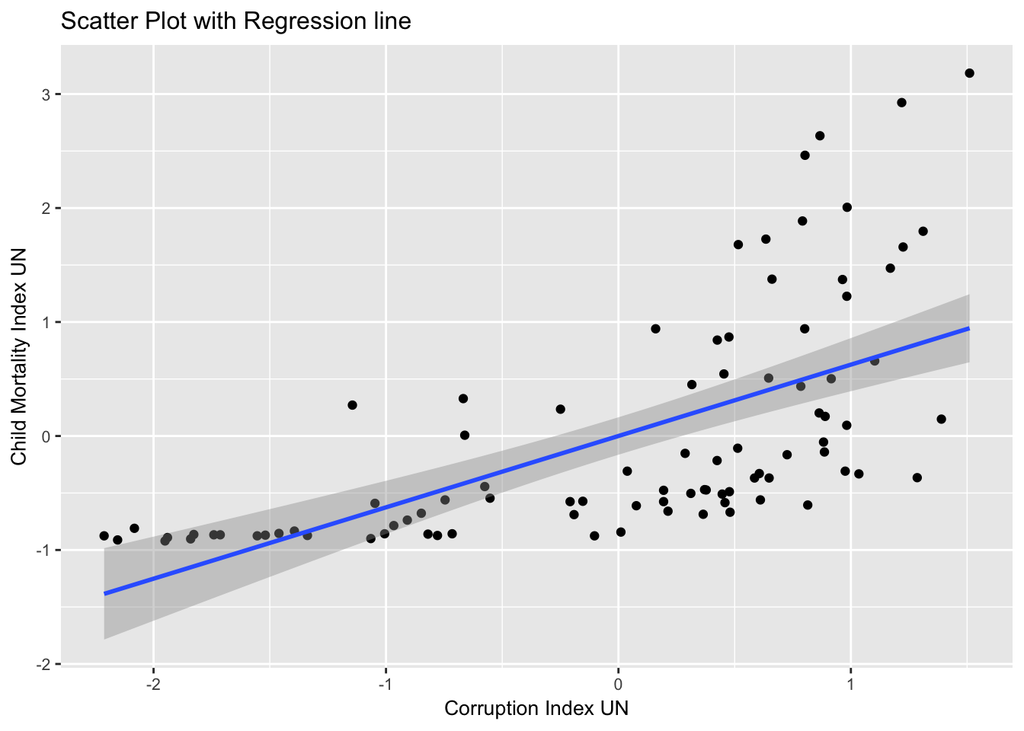

## c)

### i)

The conditions for classical measurement error are $E(\eta_i|x_i^*)=0$ and $E(\eta_i|\epsilon_i^*)=0$. It seems reasonable to assume that the later is fulfilled, a correlation between the measurement error $\eta_i$ and the true error term $\epsilon_i^*$ seems unlikely, at least there is no obvious reason for it. There might be the possibility that $E(\eta_i|x_i^*) \neq0$ as the $\eta_i$ could increase (decrease) with $x_i$ (and hence $Cov(x_i,\epsilon_i+\eta_i)\neq0$), however as we are willing to assume that the measurement error is random, we can also state that this condition is fulfilled.

Based on this, the setting is similar from the one in question 3 of the paper and pencil part. From regressing hospital death on corruption index UN, we expect the OLS estimator to be unbiased but inefficient (i.e. the variance will be larger due to the possible measurement error) since $V(x)=\sigma^2_{x^*}+\sigma^2_{\eta}$ (by slide 85 of topic 2a).

### iii)

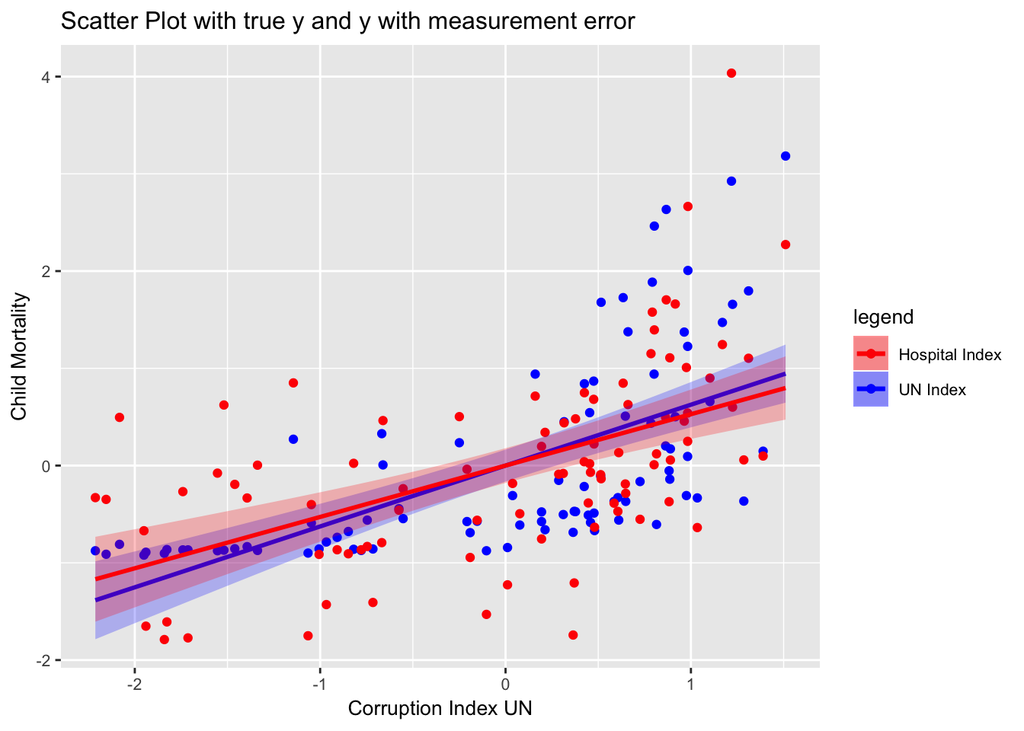

## e)

### i)

The setting is similar to question 3 in the paper and pencil part because there is as well a measurement error in the dependent variable. Although, as we assume that the classical measurement error conditions do not hold, it is not possible to consider it equivalent. In this case, we assume that the measurement error correlates to the independent variable corruption UN. Countries with a higher corruption index are more likely to report falsified figures regarding child mortality.

### ii)

The sign of the bias will probably be negative since the covariance between corruption and the measurement error in govmort is negative. A plausible story for this results could be that the countries with higher corruption index have incentives to falsify their statistics to show better performances given a lower child mortality rate than in reality.

$$\begin{align*}
E[\widehat{\beta}] &= \beta + (X'X)^{-1}X'\underbrace{E[\epsilon_i]}_{\text{=0, under A2}} + (X'X)^{-1}X'\underbrace{E[\eta_i]}_{< 0} = (X'X)^{-1}X'\underbrace{E[\eta_i]} < \beta \\
\end{align*}$$

## f)

The worst case possible is when you mistakenly assume that an estimator is unbiased whereby it is biased. In this example, the worst case is (c) because we assumed that the classical measurement error conditions are holding. This assumption is rather “strong” since there is the possibility that our measurement error correlates with the true error term. Especially in poorer countries, children have less access to hospitals than in richer one. Thus, the important variable wealth causes a bias, because we don’t control for it. As a consequence, we wrongly assume that the estimator is unbiased when it is biased.